# Assignment 3

## Variable Comparison Chart

My second chart compares the amount of black people in jail in two counties New York County and Los Angles County. I chose these two counties because of the large population densities and I wanted to see if there was any noticeable differences. There was Los Angles has a spike far earlier in the 90s then a very steep drop off which is interesting while New York has a far less pronounced spike.

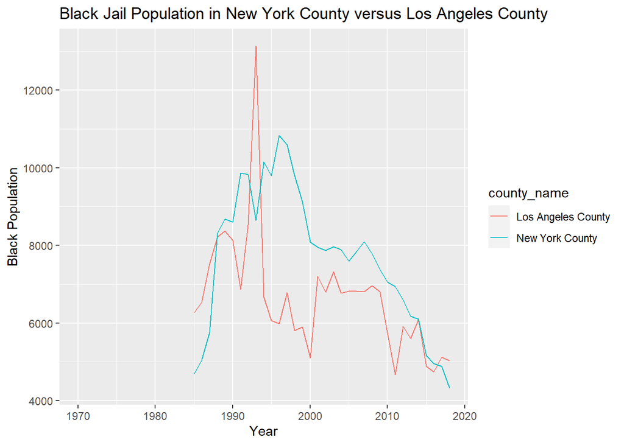

## Map

The map I created outlines the amount of black people in Jail across the US in the highest black jail year which was 1993. Looking at this map I can see that the county with the highest amount of black people in jail is in southern California, and larger populations are spread out across the country in densely populated areas like Florida and New York.

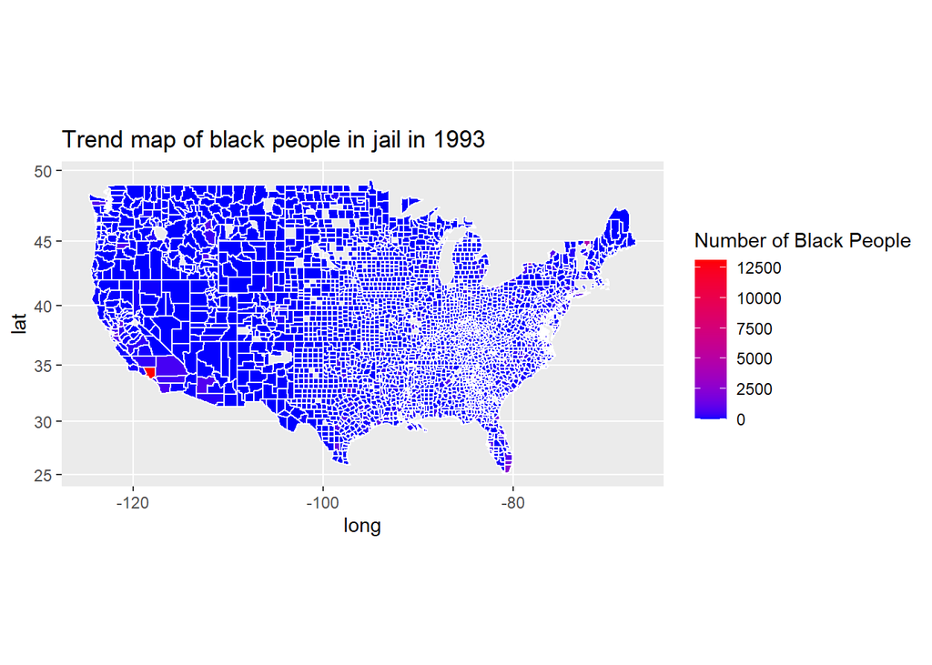